# ImaneFLE

- Show All Code
- Hide All Code
- View Source

Author

Affiliation

Imane Lattab

The University of Sydney

Published

June 3, 2026

```r
fle_data <- read.csv("../28:4:26_qualitativeIndividDiffsMotnPostnIllusions/publishedMotnPostnDataToLoad/myOverallJoV_readyForQualitativeTest.csv")
```

# Rationale

- Do some participants actually show a flash lead effect (negative FLE), rather than just noise?
- What proportion of people truly have negative effects?

For this analysis, we need *multiple observations per participant* to partition the observed variance (in degrees of visual angle, `dva`) into *true individual differences* $\sigma_\theta$ and *error variance* $\sigma_\epsilon$, i.e. variance between observations within a participant.

Hence, we collapse the data across the two sessions and estimate an overall mean (`(Intercept)`, $\mu_\theta$) and individual differences around this mean for each participant (random effect `ID`, $\sigma_\theta$).

$\mu_\theta$ = average flash-lag effect $\sigma_\theta$ = true individual differences $\sigma_\epsilon$ = trial noise (*in this case, test-retest error?*)

This represents the core model of what we understand as the FLE when true individual differences exist (however, these individual differences aren’t necessarily all caused by a single mechanism but are likely to be an amalgamation of variance).

Here, we estimate the overall mean FLE ($\mu_\theta$) and the participant-specific deviations around that mean ($\sigma_\theta$).

```r
# collapsing the sessions here
fle_lmer <- lmer(dva ~ 1 + (1 | ID), data = fle_data)

# summary(fle_lmer)

# note: only 2 within-subject measurements, should estimate better if we preserve individual trial data
# theoretical implication is that staircase method makes each trial unreliable as a standalone?
# my idea: 2 sessions * staircases(2 clockwise + 2 counterclockwise) = 8 repeated measures per ID (is this fine?)

# analysis: compare the staircases between the 2 sessions

# CONCLUSION: theoretically doesn't make sense to include staircases since the final FLE of each session isn't an average but a contrast between CW and CCW staircases
# I could technically have 2 contrasts per session, but then I'd have to decide and justify pairing one of the 2 staircases in CW and CCW
```

**Model:** $y_{ij}=\mu_\theta+\mu_i+\epsilon_{ij}$ where: $\mu_i \sim \mathcal{N}(0, \sigma_\theta)$ and: $\epsilon_{ij} \sim \mathcal{N}(0, \sigma_\epsilon)$ So each participant’s true FLE is: $\theta_i=\mu_\theta+\mu_i$

Based on the assumption of a normal distribution of individual differences $\theta_i \sim \mathcal{N}(\mu_\theta, \sigma_\theta)$, we can compute the proportion of participants with truly negative effects $p(\theta_i<0)$ as follows:

$$p(\theta_i<0) = \Phi\left(\frac{- \mu_\theta}{\sigma_\theta}\right)$$

### Maximum likelihood estimation (MLE)

**Assumptions** - Individuals are normally distributed - Individuals are independent and randomly sampled - Homoscedasticity

**Histogram**

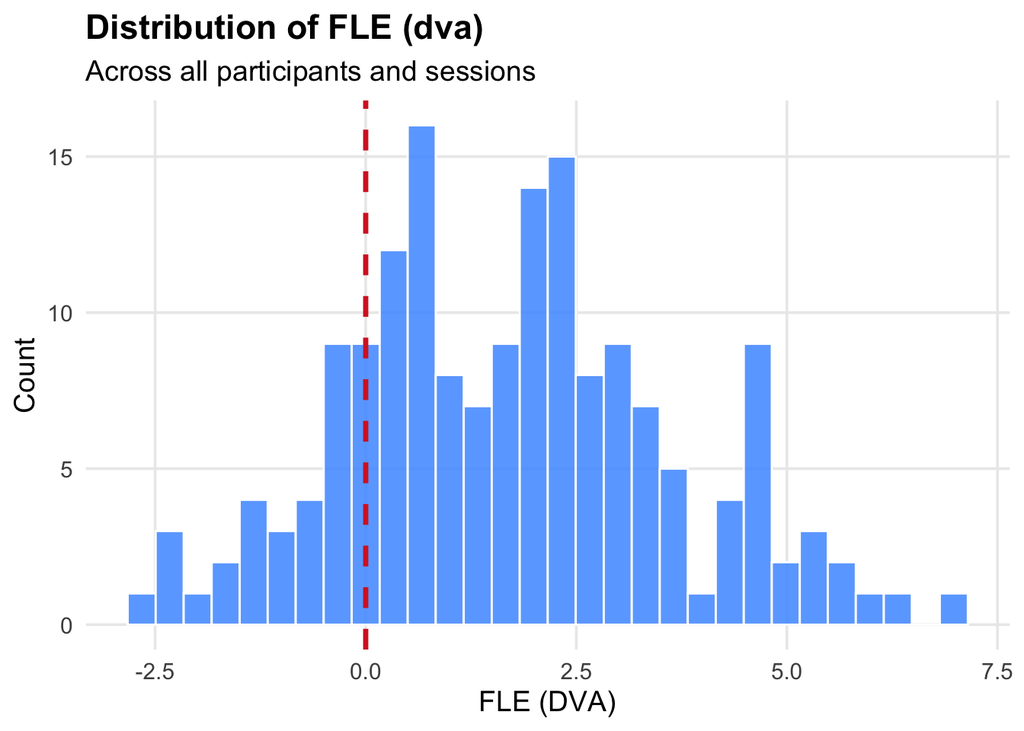

```r
# histogram
ggplot(fle_data, aes(x = dva)) +
  geom_histogram(
    bins = 30,
    fill = "#4C9AFF",
    color = "white",
    alpha = 0.85
  ) +
  geom_vline(
    xintercept = 0,
    linetype = "dashed",
    color = "#D62728",
    linewidth = 1.2
  ) +
  labs(
    title = "Distribution of FLE (dva)",
    subtitle = "Across all participants and sessions",
    x = "FLE (DVA)",
    y = "Count"
  ) +
  theme_minimal(base_size = 14) +
  theme(
    plot.title = element_text(face = "bold"),
    panel.grid.minor = element_blank()
  )
```

**Q-Q Plot**

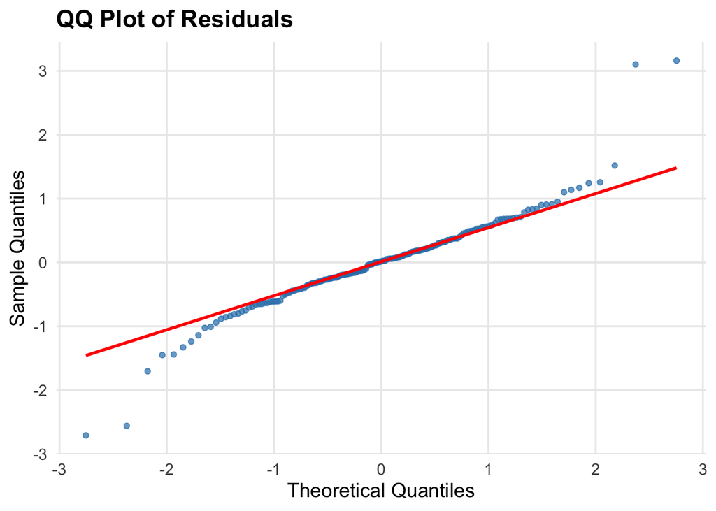

```r
# qq plot (mixed model because there is repeated-measures per individual)
model <- lmer(dva ~ session + (1 | ID), data = fle_data)

# qq plot
qq_plot <- ggplot(data.frame(resid = residuals(model)), aes(sample = resid)) +
  stat_qq(color = "#2C7FB8", alpha = 0.7) +
  stat_qq_line(color = "red", linewidth = 1) +
  labs(
    title = "QQ Plot of Residuals",
    x = "Theoretical Quantiles",
    y = "Sample Quantiles"
  ) +
  theme_minimal(base_size = 14) +
  theme(
    plot.title = element_text(face = "bold"),
    panel.grid.minor = element_blank()
  )

qq_plot
```

**Residual Plot**

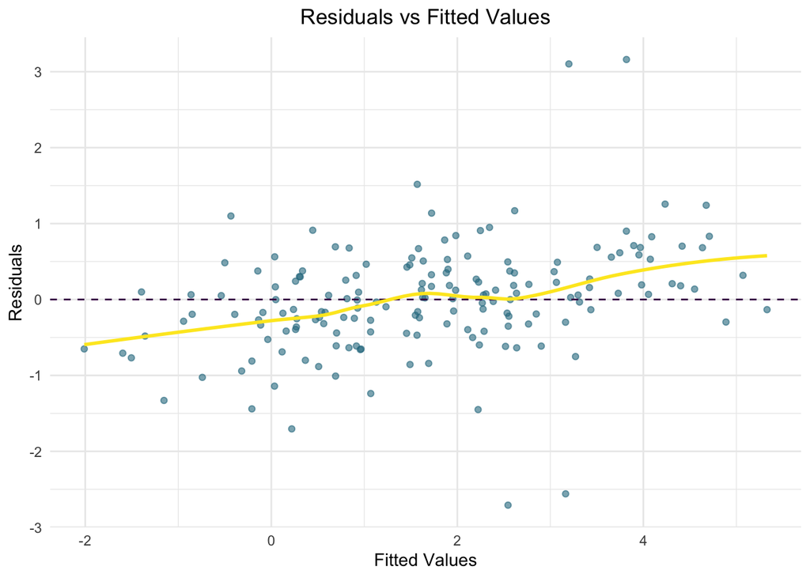

```r
# residual plot
resid_df = data.frame(
  residuals = resid(model),
  fitted = fitted(model)
)
resid_plot = resid_df |> ggplot() +
  aes(x = fitted, y = residuals) +
  geom_point(alpha = 0.6, color = "#2A788EFF") +
  geom_hline(yintercept = 0, linetype = "dashed", color = "#440154FF") +
  geom_smooth(method = "loess", se = FALSE, color = "#FDE725FF", linewidth = 1) +
  labs(title = "Residuals vs Fitted Values",
       x = "Fitted Values",
       y = "Residuals") +
  theme_minimal() +
  theme(plot.title = element_text(hjust = 0.5))

resid_plot
```

## What proportion falls below zero?

If true FLE values are normally distributed, then the proportion below 0 is area under the normal curve left to 0. We calculate this as such:

```r
mle_p_negative <- pnorm(
  q = 0 # what proportion fall below 0
  , mean = fixef(fle_lmer)[1] # overall mean FLE
  , sd = attr(VarCorr(fle_lmer)$ID, "stddev") # SD of mean FLE
)

mle_p_negative # estimated proportion of individuals who have a flash LEAD effect (negative FLE)
```

```
[1] 0.1470737
```

# Bayesian Hierarchical Model

**Plain english:** - Each observed FLE is a noisy measurement of a participant’s true FLE - Participants have different true FLE values - Those true FLE values come from a population distribution - We want to estimate how much of that population lies below zero (i.e. proportion of true negative FLE)

While the model gives an estimate proportion of “negative FLE” people, we still don’t know if this proportion is actually greater than 0.

To test whether this proportion is *credibly greater than 0*, we will fit a Bayesian hierarchical model.

Following the standard hierarchical model structure for individual differences, we define the following model:

$$\begin{aligned}
y_{ij} & \sim \mathcal{N}(\theta_i, \sigma_\epsilon) \\
\theta_i & \sim \mathcal{N}(\mu_\theta, \sigma_\theta) \\ \\
\mu_\theta & \sim \log \mathcal{N}(a_\mu, b_\mu) \\ \\
\sigma_\theta & = -\mu_\theta / \Phi^{-1}(0.5 \; p(\theta_i<0)) \\
p(\theta_i<0) & = \Phi(p^{*}_{\theta_i<0}) \\
p^{*}(\theta_i<0) & \sim \mathcal{N}(a_p, b_p) \\ \\
\sigma_\epsilon^2 & \propto 1/\sigma_\epsilon^2
\end{aligned}$$

**Model:** - $y_ij$ is the observed FLE for participant $i$ in session $j$. - $\theta_i$ is participant $i$’s underlying FLE (inferred from their 2 sessions) - $\sigma_\epsilon$ is the *within-participant* error (e.g. test-retest, measurement error) - $\mu_\theta$ is the *average FLE* in population. So if $\mu_\theta>0$, then the average person has a positive FLE. - $\sigma_\theta$ is how much true FLE differs between participants (i.e. true individual differences). This is the population-level spread of true participant effects (assumption of normal distribution). * Small $\sigma_\theta$ -> people are similar * Large $\sigma_\theta$ -> people vary a lot * Significantly large $\sigma_\theta$ -> negative FLE indivduals are plausible

We parameterize the individual differences standard deviation $\sigma_\theta$ in terms of the proportion of individuals that show a negative FLE (i.e., a flash *lead* effect, $p(\theta_i<0)$) to directly estimate this quantity of interest.

**What this does:** - $p(\theta_i<0)$ (proportion of negative FLE) becomes the parameter of interest. - Instead of estimating variance from the data to derive proportion, we estimate proportion to derive variance.

We also place a log-normal prior on the *group mean* $\mu_\theta$ to ensure positive values (but we could replace this by something more flexible).

> This prior means that we assume the average FLE is positive.

**Probit for Sampling Efficiency:** To improve sampling efficiency, we place a normal prior on the probit-transformed quantity $p^{*}(\theta_i<0)$.

> Probit model is a type of regression used to model a binary outcome. Probabilities (0-1) are hard to sample directly, but -infinity to infinity is easier. So, we sample in probit space and transform back to probability.

Finally, we place a non-informative prior on the error variance $\sigma_\epsilon^2$.

## Prior distributions

Here we define the prior assumptions (i.e. what values we think are plausible) making before fitting the Bayesian model.

Priors are placed on: 1. $p(\theta_i<0)$, proportion of true negative FLE 2. $\mu_\theta$, average true FLE 3. $\sigma_\theta$, standard deviation of true individual differences

1. **Prior Distribution for** $p(\theta_i<0)$

If the population mean is constrained to be positive and the individual effects are normally distributed, then the proportion below zero must be less than 0.5.

So; $p(\theta_i<0) \in [0, 0.5]$

We generate 100,000 simulated prior values for the proportion of people with true negative FLE.

Next, we convert these values into probabilities between 0 and 1 using normal cumulative distribution function. Remember, *proportion of negative FLE cannot be greater than 0.5* so we divide probabilities by 2.

> This prior allows some people to have true negative FLE, but no more than half the population since the population average is assumed positive.

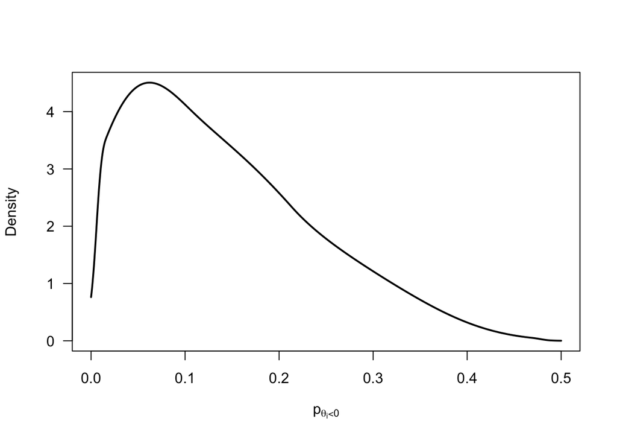

```r
# -------- PRIOR FOR negative FLE ---------
p_negative_prior <- rnorm(1e5, mean = -2/3, sd = 2/3) |>
  pnorm(0) |>
  (\(x) x / 2)()

# plausible negative FLE proportions
p_negative_prior |>
  logspline::logspline(lbound = 0, ubound = 0.5) |>
  (
    \(fit) {
      curve(
        logspline::dlogspline(x, fit)
        , from = 0, to = 0.5
        , lwd = 2
        , xlab = expression(p[theta[i] < 0])
        , ylab = "Density"
        , las = 1
        , n = 1001
      )
    }
  )()
```

2. **Prior Distribution for** $\mu_\theta$

A log-normal distribution only allows positive values. So; $\mu_\theta>0$

> This prior assumes that the average population FLE is positive.

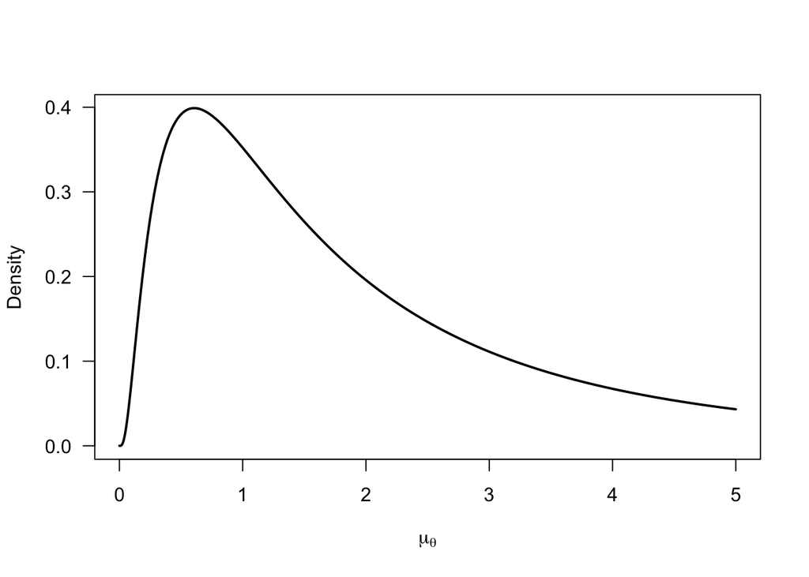

```r
curve(
  dlnorm(x, meanlog = 0.5, sdlog = 1)
  , from = 0, to = 5
  , lwd = 2
  , xlab = expression(mu[theta])
  , ylab = "Density"
  , las = 1
  , n = 1001
)
```

3. **Prior Distribution for** $\sigma_\theta$

$\sigma_\theta$ is dervied from; a) population mean; b) proportion of negative FLE.

Formula;

This is because the distribution below 0 depends on where distribution is centred ($\mu_\theta$) and how spread it is ($\sigma_\theta$).

> This prior assumes a plausible range of individual differences given negative FLE proportion and population mean.

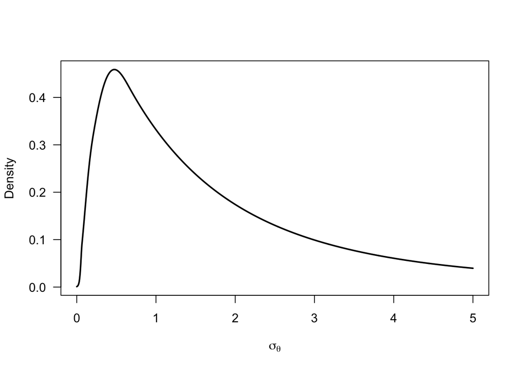

```r
# For mean: prior assumption that "FLE is typically positive"...
mu_prior <- rlnorm(1e5, meanlog = 0.5, sdlog = 1)
sigma_prior <- -mu_prior / qnorm(p_negative_prior)

# For standard deviation to ensure internal consistency
sigma_prior |>
  logspline::logspline(lbound = 0) |>
  (
    \(fit) {
      curve(
        logspline::dlogspline(x, fit)
        , from = 0, to = 5
        , lwd = 2
        , xlab = expression(sigma[theta])
        , ylab = "Density"
        , las = 1
        , n = 1001
      )
    }
  )()
```

4. **Joint Prior Visualisation**

We create a dataset of prior simulations, where each row contains one possible combination of $\mu_\theta$, $\sigma_\theta$, and $p(\theta_i<0)$.

Plot: - x-axis = possible population means - y-axis = possible individual differences (standard deviations) - colour: implied proportion of negative FLE individuals

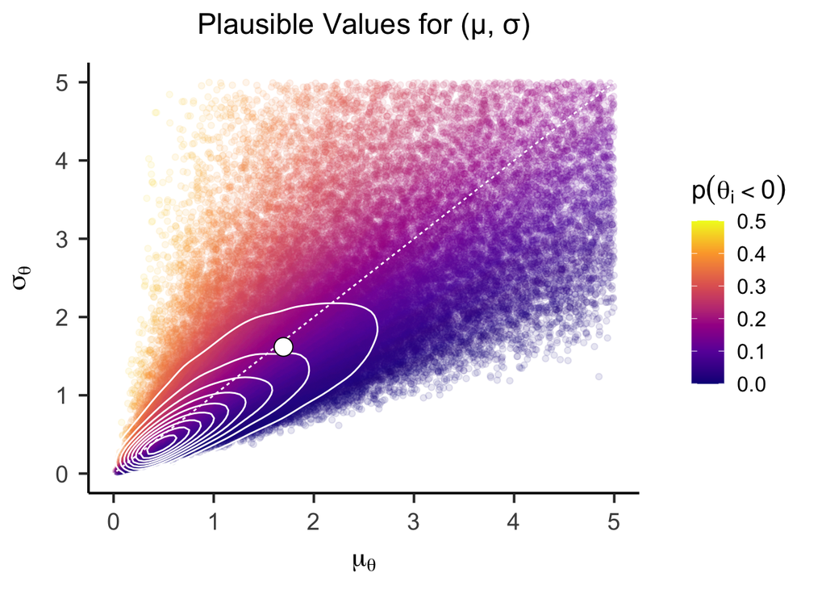

```r
# prior visualisation to show...
  # what values of (mean, sd) are plausible
  # how they relate to the parameter of interest (proportion of negative FLE)

# possible combinations of mu, theta, and negative FLE proportions:
unconstrained_joint_prior <- data.frame(mu = mu_prior, sigma = sigma_prior, p_negative = p_negative_prior) |>
  ggplot() +
    aes(x = mu, y = sigma, color = p_negative) +
    geom_point(alpha = 0.1) +
    stat_density_2d(color = "white", bins = 10) +
    geom_abline(intercept = 0, slope = 1, color = "white", linetype = "22") +
    annotate("point", x = fixef(fle_lmer)[1], y = attr(VarCorr(fle_lmer)$ID, "stddev"), shape = 21, color = "black", fill = "white", size = 5) +
    labs(
      title = "Plausible Values for (μ, σ)",
      x = expression(mu[theta])
      , y = expression(sigma[theta])
      , color = expression(p(theta[i] < 0))
    ) +
    scale_color_viridis_c(option = "C", limits = c(0, 0.5)) +
    lims(x = c(0, 5), y = c(0, 5)) +
    papaja::theme_apa(base_size = 16)

unconstrained_joint_prior
```

## Model estimation

Here we combine data with priors to produce posterior distribution, aka what we believe after updating our prior assumptions with the observed data.

### Stan Model

We use a **Markov Chain Monte Carlo** (MCMC) simulation to approximate the posterior distributions.

Approximating the true posterior for $\mu_\theta$; thousands of draws from the posterior should approximate $p(\mu_\theta|data)$

```r
# stan model
pse_model <- readLines("../28:4:26_qualitativeIndividDiffsMotnPostnIllusions/models/pse-unconstrained.stan") |>
  paste(collapse = "\n")

# preparing the data
fle_stan_data <- list(
  N = nrow(fle_data) |> as.integer() # 170 observations across everyone
  , n_subjects = length(unique(fle_data$ID)) |> as.integer() # n=85
  , id = as.integer(as.factor(fle_data$ID)) # 1-85
  , y = fle_data$dva # FLE scores in dva

# Prior settings
  # negative FLE proportion priors
  , pi_mean = -2/3
  , pi_sd = 2/3
  # mean FLE priors
  , mu_theta_mean = 0.5
  , mu_theta_sd = 1
)

# runs MCMC
fle_bayes <- rstan::stan(
  model_code = pse_model
  , data = fle_stan_data
  , iter = 1e5/4 + 1000 # 26000 iterations
  , warmup = 1000 # first 1000 samples discarded
  , chains = 4 # runs 4 independent MCMCs
  , cores = 4 # runs 4 MCMCs simultaneously
  , seed = 123
)
```

```
Trying to compile a simple C file
```

Table 1 shows the close agreement between the posterior means of the parameter estimates to the point estimates from the (restricted) maximum likelihood estimation via `lmer()`.

## Posterior Results

### Comparison of Bayesian posterior means and MLE estimates

If priors are not strongly influencing results, and our dataset is informative, then the posterior estimates should approximate the MLE estimates.

```r
data.frame(
  parameter = c("mu_theta", "sigma_theta", "sigma_epsilon", "p_negative_theta")
  , bayes = fle_bayes |>
    summary(pars = c("mu_theta", "sigma_theta", "sigma_epsilon", "p_negative_theta")) |>
    (\(x) x$summary)() |>
    as.data.frame() |>
    dplyr::pull("mean")
  , mle = c(
    fixef(fle_lmer)[1],
    attr(VarCorr(fle_lmer)$ID, "stddev"),
    sigma(fle_lmer),
    mle_p_negative
  )
) |>
  knitr::kable()
```

Table 1: Comparison of Bayesian posterior means and MLE estimates.

| parameter | bayes | mle |
| --- | --- | --- |
| mu_theta | 1.6822731 | 1.6971440 |
| sigma_theta | 1.6096287 | 1.6177654 |
| sigma_epsilon | 1.0624077 | 1.0554625 |
| p_negative_theta | 0.1485981 | 0.1470737 |

### Bayesian Model Summary

```r
fle_bayes |>
  summary(pars = c("mu_theta", "sigma_theta", "sigma_epsilon", "p_negative_theta")) |>
  (\(x) x$summary)() |>
  tidyr::as_tibble(rownames = "parameter") |>
  dplyr::mutate(
    parameter = gsub("mu", "$\\\\mu", parameter) |>
      gsub("sigma", "$\\\\sigma", x = _) |>
      gsub("_(.+)", "_{\\\\\\1}$", x = _) |>
      gsub("^p.+", "$p(\\\\theta_i<0)$", x = _)
  ) |>
  knitr::kable(digits = 3)
```

| parameter | mean | se_mean | sd | 2.5% | 25% | 50% | 75% | 97.5% | n_eff | Rhat |
| --- | --- | --- | --- | --- | --- | --- | --- | --- | --- | --- |
| $\mu_{\theta}$ | 1.682 | 0 | 0.186 | 1.316 | 1.558 | 1.682 | 1.807 | 2.049 | 151407.32 | 1 |
| $\sigma_{\theta}$ | 1.610 | 0 | 0.152 | 1.332 | 1.504 | 1.602 | 1.707 | 1.930 | 111618.71 | 1 |
| $\sigma_{\epsilon}$ | 1.062 | 0 | 0.082 | 0.916 | 1.005 | 1.057 | 1.115 | 1.238 | 57886.75 | 1 |
| $p(\theta_i<0)$ | 0.149 | 0 | 0.034 | 0.087 | 0.124 | 0.147 | 0.170 | 0.221 | 132087.49 | 1 |

### Posterior distributions

Instead of one estimate, we get full distributions over the mean, sd, and estimated negative FLE proportion.

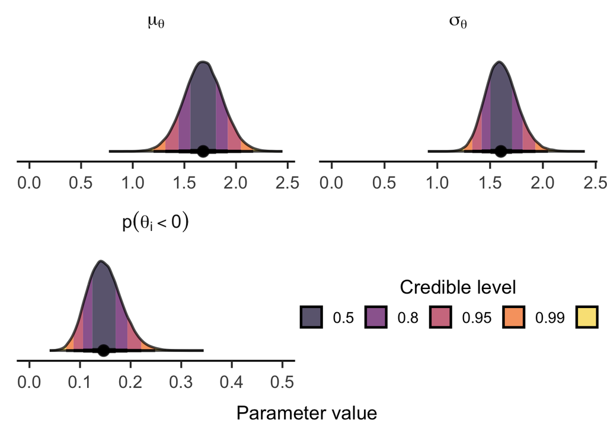

Figure 1: Posterior distributions for the group mean of individual differences $\mu_{\theta}$, the standard deviation of individual differences $\sigma_{\theta}$, and the proportion of participants with a negative flash lag effect $p(\theta_i<0)$.

```r
(tidybayes::gather_draws(
  fle_bayes
  , mu_theta, sigma_theta, p_negative_theta
) |>
  dplyr::mutate(
    .variable = factor(
      .variable
      , levels = c("mu_theta", "sigma_theta", "p_negative_theta")
      , labels = c("mu[theta]", "sigma[theta]", "p(theta[i] < 0)")
    )
  ) |>
  ggplot() +
  aes(x = .value, fill = after_stat(level)) +
  stat_halfeye(fill_type = "segments", normalize = "panels", .width = c(.5, .8, .95, .99, 1), slab_color = "black", alpha = 0.7, fatten_point = 2, interval_size_range = c(1, 2)) +
  annotate("point", x = c(0, 0.5), y = 0, color = "white") +
  scale_fill_viridis_d(option = "B", begin = 0.9, end = 0.1) +
  guides(
    fill = guide_legend(
      title = "Credible level"
      , override.aes = list(color = NA)
      , reverse = TRUE
      , direction = "horizontal"
      , title.position = "top"
      , title.hjust = 0.5
    )
  ) +
  coord_cartesian(ylim = c(-0.05, NA)) +
  facet_wrap(
    ~ .variable
    , scales = "free"
    , labeller = label_parsed
    , ncol = 2
  ) +
  labs(x = "Parameter value") +
  papaja::theme_apa(base_size = 16) +
  theme(
    axis.line.y = element_blank()
    , axis.ticks.y = element_blank()
    , axis.text.y = element_blank()
    , axis.title.y = element_blank()
    # , legend.title.position = "top"
  )) |>
  lemon::reposition_legend("center", panel = 'panel-2-2')
```

> “Most plausible values for the negative FLE proportion lie somewhere between 0 and 0.3”

## Bayes factor approximations

**Theory 1: Some negative FLE people exist.** This is the first model we will look at; the unconstrained model, where the likelihood of negative FLE is greater than 0.

**Theory 2: No one has a negative FLE.** “Stochastic dominance” idea, where $\theta_i>0$ for everyone.

> Model comparison will allow us to see if a model allowing negative FLE people is better than a model forbidding them.

Finally, we compute the Bayes factor in favor of the assumption of an unconstrained population distribution ($p(\theta_i<0) > 0$) over the strictly positive population distribution (*stochastic dominance*).

One approach is to approximate this Bayes factor using the Savage-Dickey density ratio for $p(\theta_i<0) = 0$.

$H_0 : p(\theta_i < 0) = 0$ $H_1 : p(\theta_i < 0) > 0$

> If posterior density at 0 is low, data moved away from 0 and therefore shows evidence against “no negative FLE”

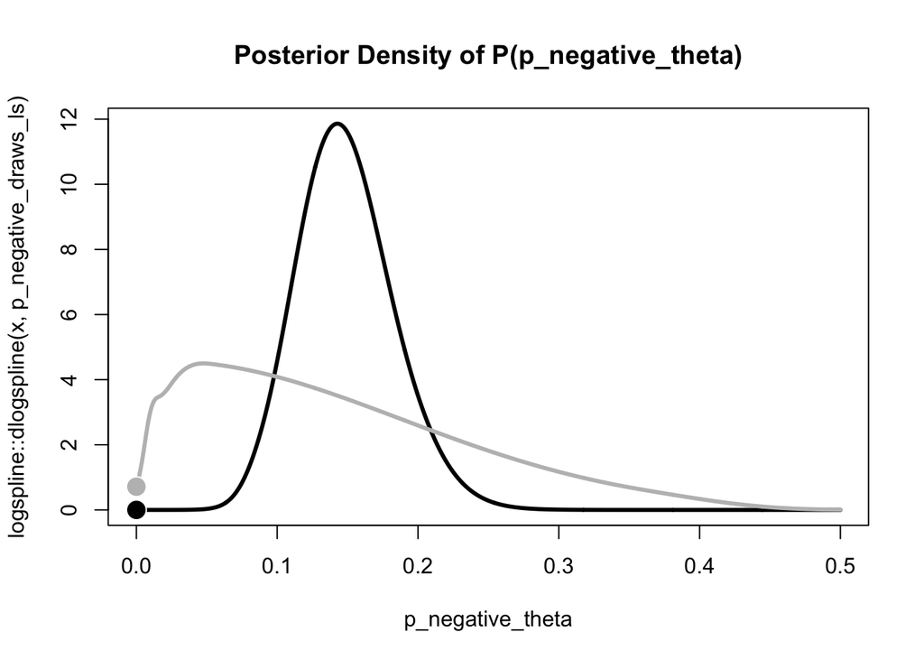

Figure 2: Posterior and prior density for the proportion of participants with a negative flash lag effect, $p(\theta_i<0)$. The Bayes factor in favor of the alternative hypothesis ($p(\theta_i<0) > 0$) over the null hypothesis ($p(\theta_i<0) = 0$) is given by the ratio of the prior density to the posterior density at $p(\theta_i<0) = 0$.

```r
# Extract posterior samples for p_negative_theta (i.e. thousands of plausible values for negative FLE proportion)
p_negative_draws <- tidybayes::gather_draws(fle_bayes, p_negative_theta)

# logspline approximation of posterior density (fits smooth density curve)
p_negative_draws_ls <- logspline::logspline(
  p_negative_draws$.value
  , lbound = 0, ubound = 0.5
)

# logspline approximation of prior density
prior_ls <- rnorm(1e5, mean = fle_stan_data$pi_mean, sd = fle_stan_data$pi_sd) |>
  pnorm() |>
  (\(x) x / 2)() |>
  logspline::logspline(lbound = 0, ubound = 0.5)

# key quantiles
prior_density <- logspline::dlogspline(0, prior_ls)
posterior_density <- logspline::dlogspline(0, p_negative_draws_ls)


curve(
  logspline::dlogspline(x, p_negative_draws_ls)
  , from = 0, to = 0.5
  , col = "black", lwd = 3
  , main = "Posterior Density of P(p_negative_theta)"
  , xlab = "p_negative_theta"
  , n = 1001
)

curve(
  logspline::dlogspline(x, prior_ls)
  , from = 0, to = 0.5
  , col = "grey", lwd = 3
  , add = TRUE
  , n = 1001
)

points(
  x = c(0, 0)
  , y = c(prior_density, posterior_density)
  , col = c("white", "white")
  , bg = c("grey", "black")
  , pch = 21
  , cex = 2
)
```

```r
bayes_factor_10 <- prior_density / posterior_density
cat("The data are", round(bayes_factor_10, 2), "times more likely under H1 than H0.\n")
```

```
The data are 68856.54 times more likely under H1 than H0.
```

We find overwhelming evidence for the unconstrained population distribution.

In other words, the assumption that noone exhibits a flash *lead* effect, seems highly implausible.

**This approach is, however, approximate and conceptually problematic.**

Under the assumption of a normal population distribution, the probability of negative effects cannot be 0, $p(\theta_i<0) \neq 0$.

> So, the null is actually IMPOSSIBLE!

## We try another approach.

We note that the null hypothesis (“no negative FLE people exist”) was impossible under the unconstrained normal distribution.

For an exact model comparison, we need to replace the assumed normal population distribution by a distribution family with support over the positive domain (e.g., truncated normal, log-normal, gamma, or inverse gamma distribution).

> This raises questions about the most appropriate distribution that lead us down the path of fitting and averaging multiple models. I will resist that temptation for now.

Instead, I approximate the strictly positive population distribution by placing a prior on $p(\theta_i<0)$ that concentrates its probability mass on very small probabilities. **This makes negative FLE people extremely rare, but still not impossible.**

1. **Prior Distribution for** $p(\theta_i<0)$

We change the prior on $p(\theta_i<0)$ by pushing almost all the probability mass near 0; *“Almost nobody has negative FLE.”*

Note that the blue curve is the previous prior and the grey curve is our new prior (i.e. negative FLE more rare).

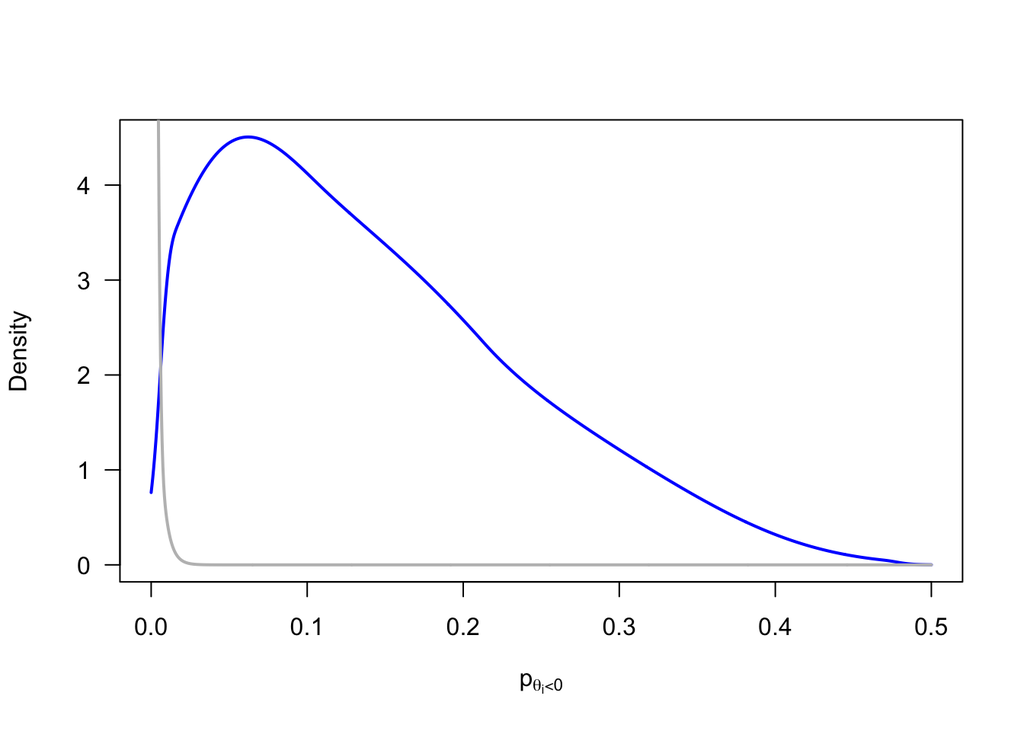

Figure 3: Comparison of priors on $p(\theta_i<0)$ for the previous unconstrained (blue) and the approximate strictly positive population distribution (grey).

```r
p_negative_prior |>
  logspline::logspline(lbound = 0, ubound = 0.5) |>
  (
    \(fit) {
      curve(
        logspline::dlogspline(x, fit)
        , from = 0, to = 0.5
        , col = "blue", lwd = 2
        , xlab = expression(p[theta[i] < 0])
        , ylab = "Density"
        , las = 1
        , n = 1001
      )
    }
  )()

# pushing mean further left
p_negative_prior <- rnorm(1e5, mean = -3.5, sd = 0.5) |>
  pnorm(0) |>
  (\(x) x / 2)()

p_negative_prior |>
  logspline::logspline(lbound = 0, ubound = 0.5) |>
  (
    \(fit) {
      curve(
        logspline::dlogspline(x, fit)
        , from = 0, to = 0.5
        , col = "grey", lwd = 2
        , add = TRUE
        , n = 1001
      )
    }
  )()
```

2. **Prior Distribution for** $\sigma_\theta$

Changing this prior also means that the $\sigma_\theta$ (i.e individual differences) prior also changes since its derived from it. It will now become smaller to prevent distribution going over 0.

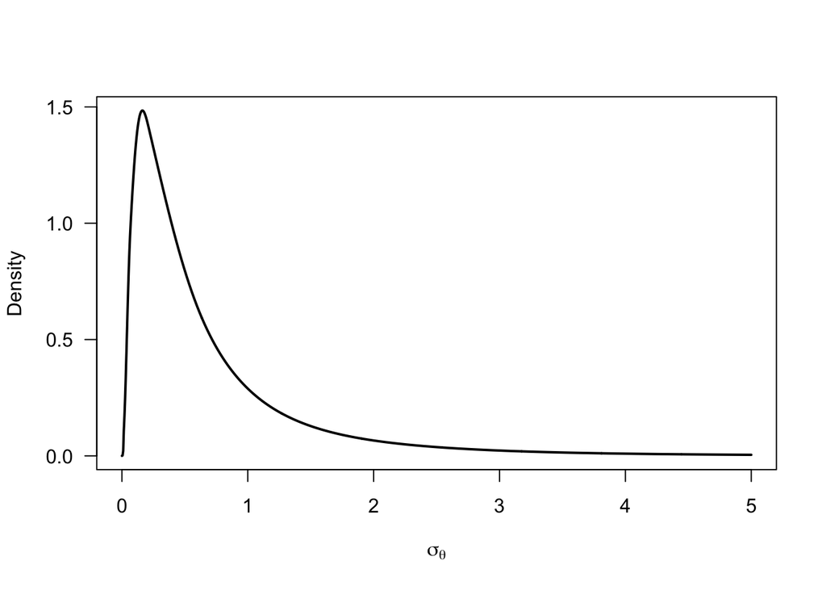

```r
# recalculates individual differences
sigma_prior <- -mu_prior / qnorm(p_negative_prior)

sigma_prior |>
  logspline::logspline(lbound = 0) |>
  (
    \(fit) {
      curve(
        logspline::dlogspline(x, fit)
        , from = 0, to = 5
        , lwd = 2
        , xlab = expression(sigma[theta])
        , ylab = "Density"
        , las = 1
        , n = 1001
      )
    }
  )()
```

3. **Joint Prior Comparison**

Original “negative FLE allowed” model vs Dominance “no negative FLE” model.

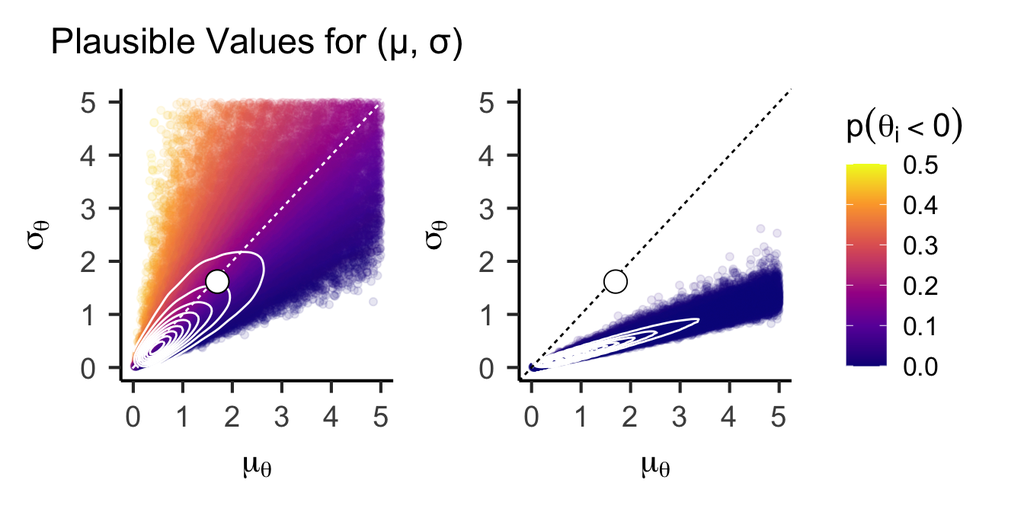

Figure 4: Comparison of joint priors on $\mu_\theta$ and $\sigma_\theta$ for the unconstrained (left) and the approximate strictly positive population distribution (right). The dotted line is the main diagonal, the white point marks the maximum likelihood estimates (MLE).

```r
dominance_joint_prior <- data.frame(mu = mu_prior, sigma = sigma_prior, p_negative = p_negative_prior) |>
  ggplot() +
    aes(x = mu, y = sigma, color = p_negative) +
    geom_point(alpha = 0.1) +
    stat_density_2d(color = "white", bins = 10) +
    geom_abline(intercept = 0, slope = 1, color = "black", linetype = "22") +
    annotate("point", x = fixef(fle_lmer)[1], y = attr(VarCorr(fle_lmer)$ID, "stddev"), shape = 21, color = "black", fill = "white", size = 5) +
    labs(
      x = expression(mu[theta])
      , y = expression(sigma[theta])
      , color = expression(p(theta[i] < 0))
    ) +
    scale_color_viridis_c(option = "C", limits = c(0, 0.5)) +
    lims(x = c(0, 5), y = c(0, 5)) +
    papaja::theme_apa(base_size = 16)

(
  unconstrained_joint_prior +
    annotate("point", x = fixef(fle_lmer)[1], y = attr(VarCorr(fle_lmer)$ID, "stddev"), shape = 21, color = "black", fill = "white", size = 5)
) +
  dominance_joint_prior +
  plot_layout(guides = "collect")
```

4. **Re-fitting the model**
- Same data
- Same MLE
- Same priors on $\mu_\theta$
- New priors on $p(\theta_i<0)$ and $\sigma_\theta$

```r
fle_stan_dominance_data <- list(
  N = nrow(fle_data) |> as.integer()
  , n_subjects = length(unique(fle_data$ID)) |> as.integer()
  , id = as.integer(as.factor(fle_data$ID))
  , y = fle_data$dva

  # Prior settings (DOMINANCE MODEL)
  , pi_mean = -3.5
  , pi_sd = 0.5
  , mu_theta_mean = 0.5
  , mu_theta_sd = 1
)

fle_dominance_bayes <- rstan::stan(
  model_code = pse_model
  , data = fle_stan_dominance_data
  , iter = 1e5/4 + 1000 * 4
  , warmup = 1000
  , chains = 4
  , cores = 4
  , seed = 123
)
```

5. **Bridge Sampling**

Estimate the Bayes factor using bridge sampling. - Estimates marginal likelihoods; $p(data | model)$ - “How much more likely is the data under;” * A model allowing negative FLE individuals * A model that makes negative FLE individuals IMPOSSIBLE

```r
unconstrained_ml <- bridge_sampler(fle_bayes, method = "warp3", repetitions = 30, silent = TRUE)
dominance_ml <- bridge_sampler(fle_dominance_bayes, method = "warp3", repetitions = 30, silent = TRUE)

bayes_factor(unconstrained_ml, dominance_ml)
```

```
Estimated Bayes factor (based on medians of log marginal likelihood estimates)
 in favor of x1 over x2: 2271892.34330
Range of estimates: 2264883.48468 to 2278279.05529
Interquartile range: 2003.88469
```

We again find overwhelming evidence for the unconstrained population distribution. In other words, the assumption that nobody exhibits a flash *lead* effect, seems highly implausible. *It is likely, however, that a comparison with a proper strictly positive population distribution would yield weaker evidence.*

# Fitting Different Models

> “This raises questions about the most appropriate distribution that lead us down the path of fitting and averaging multiple models. I will resist that temptation for now… Specification of stochastic dominance model using alternative population distribution. TBD”

## Log-normal stochastic dominance model

The previous model assumed that true individual FLE values were normally distributed. This allowed the possibility that some participants had genuinely negative true effects. However, if we want to formally compare this model against the hypothesis that nobody has a true negative FLE, we need a population distribution that has support only over positive values.

Here, we fit a log-normal stochastic dominance model. In this model, each participant’s true underlying FLE is constrained to be positive:

$$\theta_i \sim \text{LogNormal}(\mu_{\log}, \sigma_{\log})$$

The observed FLE values for participants are still modeled as noisy measurements of each participant’s true FLE (in 2 sessions):

$$y_{ij} \sim \mathcal{N}(\theta_i, \sigma_\epsilon)$$

This means that observed negative FLE values are still possible, but they are interpreted as measurement error rather than evidence that a participant’s true underlying FLE is negative.

Conceptually, this model represents the stochastic dominance hypothesis that:

> “all individuals have a positive true FLE, and any observed negative values arise from noise.”

### Fit log-normal stochastic dominance model

The previous dominance model only approximated a strictly positive population distribution by placing prior mass near $p(\theta_i<0)=0$. Here, we fit a stricter model in which true individual effects are assumed to follow a log-normal distribution. Because the log-normal distribution has support only over positive values, this model implies that no individual has a truly negative FLE. Observed negative FLE values can still occur, but only as measurement error around a positive latent effect.

#### Stan Model

- `mu_log_theta_mean` and `mu_log_theta_sd` define prior for average log-FLE.
- `sigma_log_theta_sd` controls how much true FLE can vary between people on log scale
- `sigma_epsilon_sd` weakly informative prior on measurement error (i.e. sessions)

```r
lognormal_model <- "
data {
  int<lower=1> N;
  int<lower=1> n_subjects;
  array[N] int<lower=1, upper=n_subjects> id;
  vector[N] y;

  real mu_log_theta_mean;
  real<lower=0> mu_log_theta_sd;
  real<lower=0> sigma_log_theta_sd;
  real<lower=0> sigma_epsilon_sd;
}

parameters {
  real mu_log_theta;
  real<lower=0> sigma_log_theta;
  vector[n_subjects] z_theta;
  real<lower=0> sigma_epsilon;
}

transformed parameters {
  vector<lower=0>[n_subjects] theta;

  for (i in 1:n_subjects) {
    theta[i] = exp(mu_log_theta + sigma_log_theta * z_theta[i]);
  }
}

model {
  // Priors
  mu_log_theta ~ normal(mu_log_theta_mean, mu_log_theta_sd);

  // Proper half-normal priors
  target += normal_lpdf(sigma_log_theta | 0, sigma_log_theta_sd)
            - normal_lccdf(0 | 0, sigma_log_theta_sd);

  target += normal_lpdf(sigma_epsilon | 0, sigma_epsilon_sd)
            - normal_lccdf(0 | 0, sigma_epsilon_sd);

  // Individual differences
  z_theta ~ normal(0, 1);

  // Observation model
  y ~ normal(theta[id], sigma_epsilon);
}

generated quantities {
  real mu_theta;
  real sigma_theta;
  real p_negative_theta;
  vector[N] log_lik;

  // Mean and SD of the implied log-normal population distribution
  mu_theta = exp(mu_log_theta + 0.5 * square(sigma_log_theta));

  sigma_theta = sqrt(
    (exp(square(sigma_log_theta)) - 1)
    * exp(2 * mu_log_theta + square(sigma_log_theta))
  );

  // Under a log-normal population distribution, true negative effects are impossible
  p_negative_theta = 0;

  for (n in 1:N) {
    log_lik[n] = normal_lpdf(y[n] | theta[id[n]], sigma_epsilon);
  }
}
"

dir.create("models", showWarnings = FALSE)
writeLines(lognormal_model, "models/pse-lognormal-dominance.stan")
```

#### Prepare Data

```r
fle_stan_lognormal_data <- list(
  N = nrow(fle_data) |> as.integer(),
  n_subjects = length(unique(fle_data$ID)) |> as.integer(),
  id = as.integer(as.factor(fle_data$ID)),
  y = fle_data$dva,

  # Prior settings
  mu_log_theta_mean = 0.5,
  mu_log_theta_sd = 1,
  sigma_log_theta_sd = 1,
  sigma_epsilon_sd = 5
)
```

#### Fit Log-Normal Dominance Model

> “Participants may differ in their true FLE, but every participant’s true FLE is positive.”

If model fits poorly, this suggests data contains more negative FLE observations that can plausivly be explained by measurement error alone.

```r
pse_lognormal_model <- readLines("models/pse-lognormal-dominance.stan") |>
  paste(collapse = "\n")

fle_bayes <- rstan::stan(
  model_code = pse_model,
  data = fle_stan_data,
  iter = 1e5/4 + 1000,
  warmup = 1000,
  chains = 4,
  cores = 4,
  seed = 123,

  # save all parameters needed for bridge sampling
  pars = c(
    "mu_theta",
    "sigma_theta",
    "sigma_epsilon",
    "p_negative_theta",
    "theta",
    "p_negative_theta_star"
  ),
  include = TRUE
)
```

[output not shown]

```r
fle_lognormal_bayes <- rstan::stan(
  model_code = pse_lognormal_model,
  data = fle_stan_lognormal_data,
  iter = 1e5/4 + 1000,
  warmup = 1000,
  chains = 4,
  cores = 4,
  seed = 123,

  pars = c(
    "mu_log_theta",
    "sigma_log_theta",
    "z_theta",
    "sigma_epsilon",
    "theta"
  ),
  include = TRUE
)
```

```
Trying to compile a simple C file
```

#### Summarise Model

- `mu_theta` = implied avergae true FLE on original DVA scale
- `sigma_theta` = implied between-person variability on the original DVA scale
- `sigma_epsilon` = measurement/test-retest error (i.e. sessions)
- `p_negative_theta`: fixed at 0 because true negative effects are impossible under the log-normal model

```r
fle_lognormal_bayes |>
  summary(
    pars = c(
      "mu_log_theta",
      "sigma_log_theta",
      "sigma_epsilon"
    )
  ) |>
  (\(x) x$summary)() |>
  tidyr::as_tibble(rownames = "parameter") |>
  knitr::kable(digits = 3)
```

| parameter | mean | se_mean | sd | 2.5% | 25% | 50% | 75% | 97.5% | n_eff | Rhat |
| --- | --- | --- | --- | --- | --- | --- | --- | --- | --- | --- |
| mu_log_theta | 0.251 | 0.001 | 0.140 | -0.046 | 0.163 | 0.260 | 0.348 | 0.501 | 43260.82 | 1 |
| sigma_log_theta | 0.851 | 0.001 | 0.133 | 0.616 | 0.759 | 0.842 | 0.934 | 1.140 | 20947.62 | 1 |
| sigma_epsilon | 1.311 | 0.001 | 0.103 | 1.127 | 1.239 | 1.304 | 1.376 | 1.530 | 28768.99 | 1 |

#### Compare Posteriors

Plot shows what values of population mean, individual-differences SD, and measurement error SD are plausible under the log-normal model.

`sigma_epsilon`: if model needs a large $\sigma_\epsilon$, it may be explaining negative FLE as measurement error rather than genuine negative individual effects.

Reminder that under the log-normal dominance model, true individual FLE values are constrained to be positive. Therefore:

$$p(\theta_i<0)=0$$

The key parameters are:

- $\mu_\theta$: implied average true FLE on the original dva scale
- $\sigma_\theta$: implied true individual differences on the original dva scale
- $\sigma_\epsilon$: measurement/test-retest error on the original dva scale

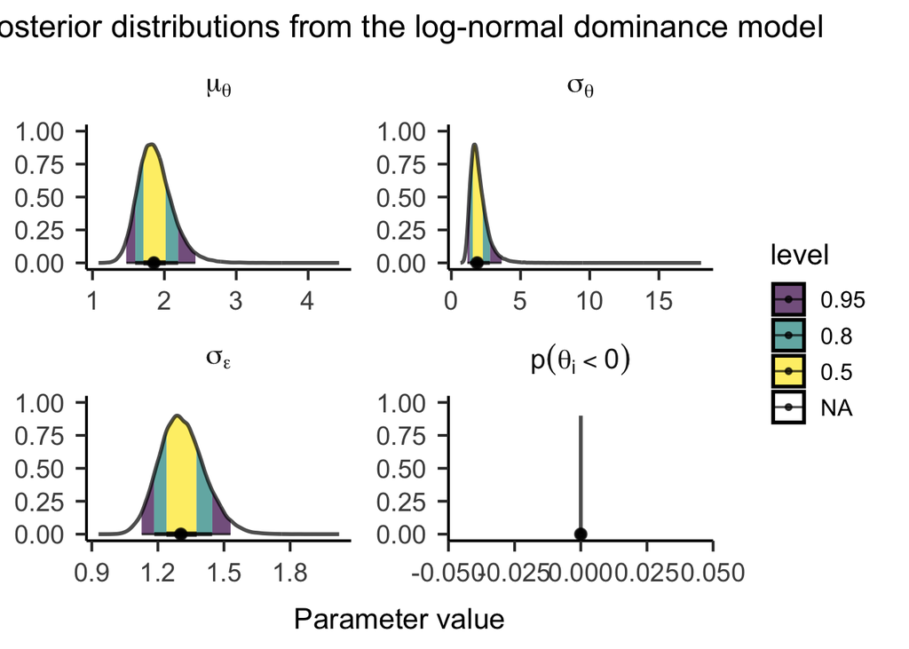

```r
#| label: lognormal-posterior-prediction

lognormal_posterior <- as.data.frame(rstan::extract(fle_lognormal_bayes))

lognormal_posterior <- lognormal_posterior |>
  dplyr::mutate(
    mu_theta = exp(mu_log_theta + 0.5 * sigma_log_theta^2),
    sigma_theta = sqrt(
      (exp(sigma_log_theta^2) - 1) *
        exp(2 * mu_log_theta + sigma_log_theta^2)
    ),
    p_negative_theta = 0
  )

lognormal_draws <- lognormal_posterior |>
  dplyr::select(mu_theta, sigma_theta, sigma_epsilon, p_negative_theta) |>
  tidyr::pivot_longer(
    cols = everything(),
    names_to = ".variable",
    values_to = ".value"
  ) |>
  dplyr::mutate(
    .variable = factor(
      .variable,
      levels = c("mu_theta", "sigma_theta", "sigma_epsilon", "p_negative_theta"),
      labels = c("mu[theta]", "sigma[theta]", "sigma[epsilon]", "p(theta[i] < 0)")
    )
  )

lognormal_draws |>
  ggplot() +
  aes(x = .value, fill = after_stat(level)) +
  tidybayes::stat_halfeye(
    fill_type = "segments",
    normalize = "panels",
    .width = c(.5, .8, .95),
    slab_color = "black",
    alpha = 0.7
  ) +
  facet_wrap(
    ~ .variable,
    scales = "free",
    labeller = label_parsed
  ) +
  labs(
    x = "Parameter value",
    y = NULL,
    title = "Posterior distributions from the log-normal dominance model"
  ) +
  papaja::theme_apa(base_size = 16)
```

#### Summary Table on Original Scale

```r
lognormal_posterior |>
  dplyr::select(mu_theta, sigma_theta, sigma_epsilon, p_negative_theta) |>
  tidyr::pivot_longer(
    cols = everything(),
    names_to = "parameter",
    values_to = "value"
  ) |>
  dplyr::group_by(parameter) |>
  dplyr::summarise(
    mean = mean(value),
    sd = sd(value),
    `2.5%` = quantile(value, .025),
    `50%` = quantile(value, .5),
    `97.5%` = quantile(value, .975),
    .groups = "drop"
  ) |>
  knitr::kable(digits = 3)
```

| parameter | mean | sd | 2.5% | 50% | 97.5% |
| --- | --- | --- | --- | --- | --- |
| mu_theta | 1.879 | 0.245 | 1.471 | 1.854 | 2.431 |
| p_negative_theta | 0.000 | 0.000 | 0.000 | 0.000 | 0.000 |
| sigma_epsilon | 1.311 | 0.103 | 1.127 | 1.304 | 1.530 |
| sigma_theta | 1.998 | 0.660 | 1.156 | 1.863 | 3.623 |

#### Compare to Unconstrained Model

**Unconstrained:**
$$M1: \theta_i \sim \mathcal{N}(\mu_\theta, \sigma_\theta)$$

**Log-Normal:**
$$M0: \theta_i \sim LogNormal(\mu_{log\theta}, \sigma_{log\theta})$$

```r
# error, but just run stan again and it works (need to check)
fle_bayes <- rstan::stan(
  model_code = pse_model,
  data = fle_stan_data,
  iter = 1e5/4 + 1000,
  warmup = 1000,
  chains = 4,
  cores = 4,
  seed = 123
)

# should work now
unconstrained_ml <- bridgesampling::bridge_sampler(
  fle_bayes,
  method = "warp3",
  repetitions = 30,
  silent = TRUE
)

lognormal_ml <- bridgesampling::bridge_sampler(
  fle_lognormal_bayes,
  method = "warp3",
  repetitions = 30,
  silent = TRUE
)
```

```r
bridgesampling::bayes_factor(unconstrained_ml, lognormal_ml)
```

```
Estimated Bayes factor (based on medians of log marginal likelihood estimates)
 in favor of x1 over x2: 0.00000
Range of estimates: 0.00000 to 0.00000
Interquartile range: 0.00000
```

I think something went wrong here, but why BF is 0 could be; - true BF is very small and log-normal is preferred model - bridge sampling failed (likely, since i’ve been trying to debug) - models are not actually comparable (i.e they’re using different priors)

Asked ChatGPT, apaprently the bridge sampling worked but suspects modelling issue. Suspects that the models are incomparable and that unconstrained model uses an improper prior.

## Summary for Log-Normal

Preliminary bridge-sampling comparisons strongly favored the log-normal model. However, because the competing models differed substantially in their parameterisation and prior structure, these Bayes factors are difficult to interpret as evidence for or against the existence of true negative FLE individuals.

# Error checking

check implied population quantiles

```r
summary(fle_lognormal_bayes,
        pars = c(
          "mu_log_theta",
          "sigma_log_theta",
          "sigma_epsilon"
        ))
```

```
$summary
                     mean      se_mean        sd        2.5%      25%       50%
mu_log_theta    0.2512455 0.0006713655 0.1396389 -0.04610203 0.162850 0.2599304
sigma_log_theta 0.8512150 0.0009219210 0.1334323  0.61566638 0.758693 0.8420205
sigma_epsilon   1.3107431 0.0006063238 0.1028411  1.12660839 1.238761 1.3044076
                      75%     97.5%    n_eff     Rhat
mu_log_theta    0.3478001 0.5012065 43260.82 1.000036
sigma_log_theta 0.9336701 1.1396872 20947.62 1.000168
sigma_epsilon   1.3759764 1.5295365 28768.99 1.000067

$c_summary
, , chains = chain:1

                 stats
parameter              mean        sd        2.5%       25%       50%       75%
  mu_log_theta    0.2494584 0.1411215 -0.05493878 0.1595506 0.2588176 0.3475133
  sigma_log_theta 0.8525304 0.1339986  0.61938977 0.7592887 0.8416359 0.9357394
  sigma_epsilon   1.3098292 0.1015715  1.12555865 1.2395486 1.3038115 1.3742785
                 stats
parameter             97.5%
  mu_log_theta    0.4983496
  sigma_log_theta 1.1454087
  sigma_epsilon   1.5230581

, , chains = chain:2

                 stats
parameter              mean        sd        2.5%       25%       50%       75%
  mu_log_theta    0.2517627 0.1404505 -0.05020305 0.1630609 0.2605798 0.3490098
  sigma_log_theta 0.8497130 0.1343068  0.61152122 0.7557365 0.8408560 0.9321542
  sigma_epsilon   1.3113147 0.1033902  1.12541213 1.2387556 1.3053209 1.3770882
                 stats
parameter            97.5%
  mu_log_theta    0.504603
  sigma_log_theta 1.138167
  sigma_epsilon   1.531362

, , chains = chain:3

                 stats
parameter              mean        sd        2.5%       25%       50%       75%
  mu_log_theta    0.2507022 0.1393411 -0.04416246 0.1625204 0.2587846 0.3464246
  sigma_log_theta 0.8515181 0.1323256  0.61432353 0.7608902 0.8432894 0.9327467
  sigma_epsilon   1.3110604 0.1037129  1.12539548 1.2381833 1.3041488 1.3776427
                 stats
parameter             97.5%
  mu_log_theta    0.5020164
  sigma_log_theta 1.1380448
  sigma_epsilon   1.5319239

, , chains = chain:4

                 stats
parameter              mean        sd        2.5%       25%       50%       75%
  mu_log_theta    0.2530587 0.1376001 -0.03787895 0.1662159 0.2615720 0.3481671
  sigma_log_theta 0.8510985 0.1330819  0.61796273 0.7585970 0.8424217 0.9335276
  sigma_epsilon   1.3107682 0.1026769  1.12940963 1.2387181 1.3042091 1.3750573
                 stats
parameter            97.5%
  mu_log_theta    0.500413
  sigma_log_theta 1.137559
  sigma_epsilon   1.530905
```

```r
post <- as.data.frame(rstan::extract(fle_lognormal_bayes))

mean(exp(post$mu_log_theta + 0.5*post$sigma_log_theta^2))
```

```
[1] 1.878758
```

```r
mean(
  sqrt(
    (exp(post$sigma_log_theta^2)-1) *
      exp(
        2*post$mu_log_theta +
          post$sigma_log_theta^2
      )
  )
)
```

```
[1] 1.998187
```

check how many people had negative FLE

```r
fle_data |>
  dplyr::group_by(ID) |>
  dplyr::summarise(mean_fle = mean(dva)) |>
  dplyr::summarise(
    n_negative = sum(mean_fle < 0),
    prop_negative = mean(mean_fle < 0)
  )
```

```
# A tibble: 1 × 2
  n_negative prop_negative
       <int>         <dbl>
1         15         0.176
```